# Demo Java call R

Ming Cao

February 2, 2016

我在这儿演示一个大数据前端（假设为Java写的Spark）如何调用R的分析（LASSO Cox Regression for Survival data）并使用Rmarkdown（knitr）生成包含可交互的可视化图形（D3）的网页。

#### 第一步

把glmnet这个R package自带的数据集CoxExample存成csv格式，作为数据源。

```r
library(glmnet)
data(CoxExample)
setwd("C:/Users/Ming/Dropbox/2015/xu/JRI")
write.csv(data.frame(y, x), file = "CoxExample.csv", quote = FALSE, row.names = FALSE)
```

#### 第二步

在Eclipse里面配置一个单机的Spark环境：新建一个Maven Project，往pom.xml文件里面添加两个dependencies：spark-core和spark-csv（第二个只是为了方便读写csv file）

```r
    <dependencies>
        <dependency> <!-- Spark dependency -->
            <groupId>org.apache.spark</groupId>
            <artifactId>spark-core_2.10</artifactId>
            <version>1.6.0</version>
        </dependency>

        <dependency>
            <groupId>com.databricks</groupId>
            <artifactId>spark-csv_2.10</artifactId>
            <version>1.3.0</version>
        </dependency>
    </dependencies>
```

#### 第三步

使用Spark SQL提供的DataFrame（而不是更basic的RDD）来连接数据源。虽然我们的例子是一个最简单的本地文件，但是只要连好了DataBase或者HDFS，后面的接口都是一样的，这不是重点。

```r
        String wd = "C:/Users/Ming/Dropbox/2015/xu/JRI";
        SparkConf conf = new SparkConf().setAppName("Ming's Demo").setMaster("local");
        JavaSparkContext sc = new JavaSparkContext(conf);
        SQLContext sqlContext = new SQLContext(sc);
        DataFrame df = sqlContext.read()
                .format("com.databricks.spark.csv")
                .option("inferSchema", "true")
                .option("header", "true")
                .load(wd + "/CoxExample.csv");
        df.show();
        df.printSchema();
```

可以从Spark官网下一个Build好的，新建一个User Library，把lib下面的jar都放进去，然后给spark-assembly这个jar添加javadoc location为http://spark.apache.org/docs/latest/api/java，这样就可以看到API文档了。因为默认是不带Windows玩的，我又想避免在Windows下面做Build的麻烦，就直接从[这个网站](https://www.barik.net/archive/2015/01/19/172716/)下了一个64位的Windows Binary（including winutils.exe），在Eclipse的Run/Debug Configuration中设置Hadoop_Home到解压后的目录。

#### 第四步

如果想在内存中直接传递数据到R中做分析（避免I/O），目前貌似只有[Java/R Interface](http://www.rforge.net/JRI/index.html)这个选择：可能是反向的R调用Java更普遍，JRI现在是rJava的一部分

```r
install.packages("rJava")
```

把local R repository下面的jar加到Java library中，同时新建一个dll目录存放jri.dll并在 Java Build Path -> Source -> Native library location -> workspace下选择这个目录，以及设置R_HOME, for example, =C:\Program Files\R\R-3.1.1和PATH, for example, =C:\Program Files\R\R-3.1.1\bin\x64, so that R.dll can be found。 一般的做法就是在JVM外新开一个R线程：

```r
        if(!Rengine.versionCheck())
        {
            System.err.println("** Version mismatch - Java files don't match library version.");
            System.exit(1);
        }
        System.out.println("Creating Rengine (with arguments)");
        Rengine re = new Rengine(args, false, null);
        System.out.println("Rengine created, waiting for R");
        // the engine creates R is a new thread, so we should wait until it is ready
        if (!re.waitForR()) {
            System.out.println("Cannot load R");
            return;
        }
```

R运行的结果用REXP类型来接：

```r
            REXP x;
            re.eval("data(iris)",false);
            System.out.println(x=re.eval("head(iris)"));
```

或者把Java数组assign给R：

```r
      boolean by[] = { true, false, false };
            re.assign("bool", by);
            System.out.println(x=re.eval("bool"));
```

因为涉及到数据类型（Type）之间的一一对应，JRI适合比较基础的旧Java项目，但在Spark Dataframe这种框架下就不但繁琐，且必须先把数据集collect到本地：

```r
      Object t = df.rdd().collect();
```

试想对于一个能在本地内存装的下的data，又何必去折腾这些底层的东西呢？直接存个文件让R去读不就好了吗，所以这一步不再继续讨论了。

#### 第五步

实际应用中，往往是根据条件去筛选数据，比如吃过某种药的病人的死亡时间和性别：

```r
      df.filter(df.col("drug").equalTo("Penicillin")).select("time", "gender")
```

这样得到的数据一般就是R能读取的大小了，写入文件：

```r
      df.filter(df.col("drug").equalTo("Penicillin")).select("time", "gender")
      .repartition(1)
      .write().mode("overwrite")
      .format("com.databricks.spark.csv")
      .option("header", "true")
      .save(wd + "/CoxExampleSpark.csv");
```

这里唯一比较annoying的是尽管指明了csv也repartition成了一块，Spark还是存成了CoxExampleSpark.csv\part-00000这种形式，我也懒得处理了，就直接把这个path传给R吧。

#### 第六步

因为我们不但想利用R最大的优势：由统计学家贡献的packages做分析，还想把结果在网页上（最好还能是可交互的）呈现，所以可以用RMarkdown的方式把文字和代码（运行结果）放在一起。更丰富的应用也可以使用Shiny：RStudio的Web框架。这里就简单地画一个Survival Analysis中的Kaplan-Meier Estimator（传说中引用率最高到没有之一的统计方法），然后用glmnet包跑个LASSO：

```r
library(methods) #for it to work properly under Rscript
input = commandArgs(trailingOnly = TRUE)[2]

#input = 'C:/Users/Ming/Dropbox/2015/xu/JRI/CoxExampleSpark.csv/part-00000'
print(paste('reading data from', input))
```

```
## [1] "reading data from C:/Users/Ming/Dropbox/2015/xu/JRI/CoxExampleSpark.csv/part-00000"
```

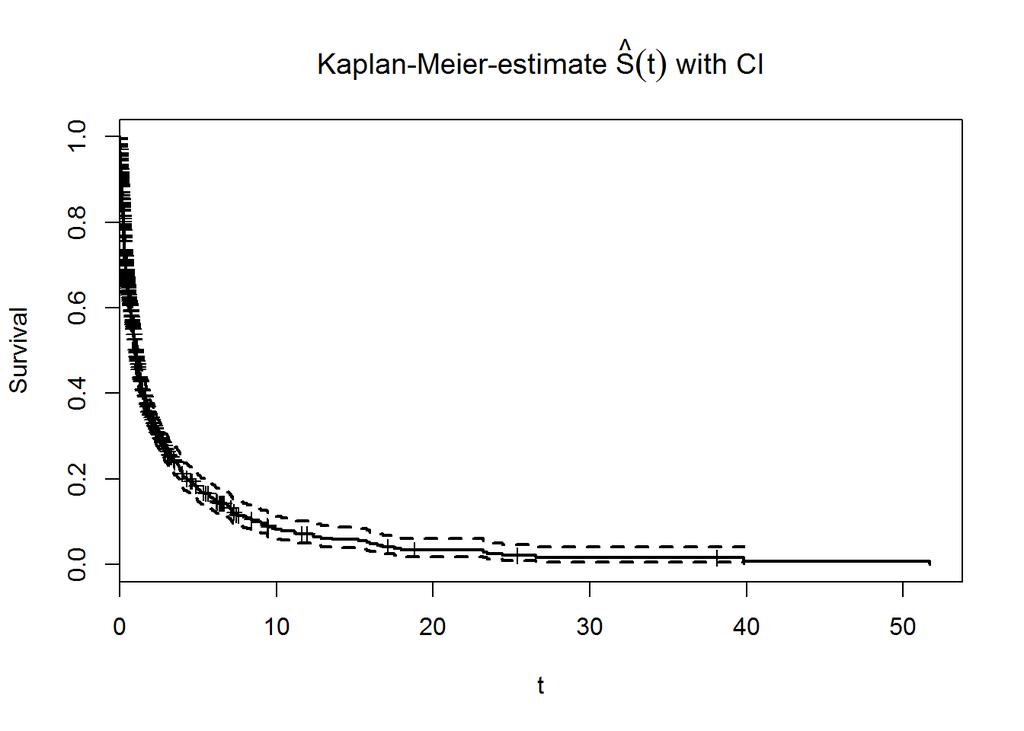

```r
dat = read.csv(input)
x = as.matrix(dat[, -c(1,2)])
y = as.matrix(dat[, c('time', 'status')])

library(survival)

KM0 <- survfit(Surv(time, status) ~ 1,  type="kaplan-meier", conf.type="log", data=dat)
plot(KM0, main=expression(paste("Kaplan-Meier-estimate ", hat(S)(t), " with CI")),
     xlab="t", ylab="Survival", lwd=2)
```

```r
fit = glmnet(x, y, family = "cox")
summary(fit)
```

```
##           Length Class     Mode
## a0           0   -none-    NULL
## beta      1470   dgCMatrix S4
## df          49   -none-    numeric
## dim          2   -none-    numeric
## lambda      49   -none-    numeric
## dev.ratio   49   -none-    numeric
## nulldev      1   -none-    numeric
## npasses      1   -none-    numeric
## jerr         1   -none-    numeric
## offset       1   -none-    logical
## call         4   -none-    call
## nobs         1   -none-    numeric
```

随着D3这类框架的成熟，就可以赋予用户一定的自由度去explore data，调整visualization了。plotly这是提供这种功能的一个package，这儿仅以它自带的一个例子做的Demo：

```r
library(plotly)
set.seed(100)
d <- diamonds[sample(nrow(diamonds), 1000), ]
plot_ly(d, x = carat, y = price, text = paste("Clarity: ", clarity),
        mode = "markers", color = carat, size = carat)
```

[interactive chart not shown]

#### 最后一步

在原来的Java程序中，只要系统调用就可以了：

```r
        String comd = "Rscript -e \"rmarkdown::render('" + wd + "/demo.Rmd')\" --args "
                + wd + "/CoxExampleSpark.csv/part-00000";
        System.out.println("run R command line: " + comd);
        try{
            Runtime.getRuntime().exec(comd);
        }catch(Exception e){
            e.printStackTrace();
        }
```

不同于在RStudio里面knit HTML的一个小技巧就是在R里面调用rmarkdown::render，这样才能把命令行的参数传进生成本文档的.Rmd运行环境里。